# Homework_5

Claire Kraft

2024-09-22

## Question 8.1

**Describe a situation or problem from your job, everyday life, current events, etc., for which a linear regression model would be appropriate. List some (up to 5) predictors that you might use.**

Climbing

Using linear regression to track my climbing progress could be helpful and object. Climbing has several climbing grades depending on what type of climbing you do. I’ll just speak about lead climbing which uses the Yosemite or YDS grading scale. The linear regression could use these independent variables: climbing frequency, training hours, rest days, body measurements, onsight difficulty. To onsight in sports climbing means to reach the top on the first try with little information or mistake.

The formula [1]:
$$\text{Climbing Difficulty} = \beta_0 + \beta_1 (\text{Climbing
Frequency}) + \beta_2 (\text{Training Hours}) + \beta_3 (\text{Rest
Days}) + \beta_4 (\text{Body Measurements}) + \beta_5 (\text{Onsight
Difficulty}) + \epsilon$$

## Question 8.2

**Using crime data from http://www.statsci.org/data/general/uscrime.txt (file uscrime.txt, description at http://www.statsci.org/data/general/uscrime.html ), use regression (a useful R function is lm or glm) to predict the observed crime rate in a city with the following data:**

```
  M = 14.0
  So = 0
  Ed = 10.0
  Po1 = 12.0
  Po2 = 15.5
  LF = 0.640
  M.F = 94.0 Pop = 150
  NW = 1.1
  U1 = 0.120
  U2 = 3.6
  Wealth = 3200
  Ineq = 20.1
  Prob = 0.04
  Time = 39.0
```

**Show your model (factors used and their coefficients), the software output, and the quality of fit.**

**Note that because there are only 47 data points and 15 predictors, you’ll probably notice some overfitting. We’ll see ways of dealing with this sort of problem later in the course.**

The formula [2]:
$$R^2 = 1 -
\frac{SS_{res}}{SS_{tot}}$$

Where: - $R^2$ is the R-squared value - $SS_{res}$ is the sum of squares of the residuals - $SS_{tot}$ is the total sum of squares

```r
# Remove all objects from the current workspace
rm(list = ls())

# Load necessary libraries
library(DAAG)

# Read the data from the specified file path into a data frame
uscrime <- read.table("C://Users//Clair//OneDrive//Documents//GitHub//omsa//ISYE 6501//Homework 5//uscrime.txt", stringsAsFactors = FALSE, header = TRUE)

# Fit a linear model to the data with 'Crime' as the response variable and all other variables as predictors
lm_uscrime <- lm(Crime ~ ., data = uscrime)

# Display the linear model object
lm_uscrime
```

```
##
## Call:
## lm(formula = Crime ~ ., data = uscrime)
##
## Coefficients:
## (Intercept)            M           So           Ed          Po1          Po2
##  -5.984e+03    8.783e+01   -3.803e+00    1.883e+02    1.928e+02   -1.094e+02
##          LF          M.F          Pop           NW           U1           U2
##  -6.638e+02    1.741e+01   -7.330e-01    4.204e+00   -5.827e+03    1.678e+02
##      Wealth         Ineq         Prob         Time
##   9.617e-02    7.067e+01   -4.855e+03   -3.479e+00
```

```r
# Display a summary of the linear model, including coefficients, R-squared, etc.
summary(lm_uscrime)
```

```
##
## Call:
## lm(formula = Crime ~ ., data = uscrime)
##
## Residuals:
##     Min      1Q  Median      3Q     Max
## -395.74  -98.09   -6.69  112.99  512.67
##
## Coefficients:
##               Estimate Std. Error t value Pr(>|t|)
## (Intercept) -5.984e+03  1.628e+03  -3.675 0.000893 ***
## M            8.783e+01  4.171e+01   2.106 0.043443 *
## So          -3.803e+00  1.488e+02  -0.026 0.979765
## Ed           1.883e+02  6.209e+01   3.033 0.004861 **
## Po1          1.928e+02  1.061e+02   1.817 0.078892 .
## Po2         -1.094e+02  1.175e+02  -0.931 0.358830
## LF          -6.638e+02  1.470e+03  -0.452 0.654654
## M.F          1.741e+01  2.035e+01   0.855 0.398995
## Pop         -7.330e-01  1.290e+00  -0.568 0.573845
## NW           4.204e+00  6.481e+00   0.649 0.521279
## U1          -5.827e+03  4.210e+03  -1.384 0.176238
## U2           1.678e+02  8.234e+01   2.038 0.050161 .
## Wealth       9.617e-02  1.037e-01   0.928 0.360754
## Ineq         7.067e+01  2.272e+01   3.111 0.003983 **
## Prob        -4.855e+03  2.272e+03  -2.137 0.040627 *
## Time        -3.479e+00  7.165e+00  -0.486 0.630708
## ---
## Signif. codes:  0 '***' 0.001 '**' 0.01 '*' 0.05 '.' 0.1 ' ' 1
##
## Residual standard error: 209.1 on 31 degrees of freedom
## Multiple R-squared:  0.8031, Adjusted R-squared:  0.7078
## F-statistic: 8.429 on 15 and 31 DF,  p-value: 3.539e-07
```

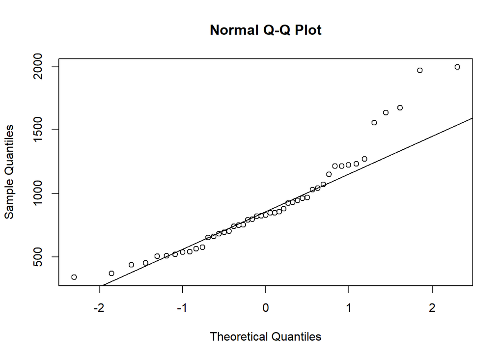

```r
# Check the normality of the 'Crime' variable in the dataset using a Q-Q plot
qqnorm(uscrime$Crime)
qqline(uscrime$Crime)
```

```r
# Calculate the total sum of squares (SST)
total_sum_squared_diff <- sum((uscrime$Crime - mean(uscrime$Crime))^2)
total_sum_squared_diff
```

```
## [1] 6880928
```

```r
# Calculate the sum of squares of the residuals (SSE)
sum_squared_residuals <- sum(residuals(lm_uscrime)^2)

# Calculate R-squared
r_squared <- 1 - (sum_squared_residuals / total_sum_squared_diff)
r_squared
```

```
## [1] 0.8030868
```

```r
# Perform 5-fold cross-validation
set.seed(42)
cv_results <- cv.lm(uscrime, lm_uscrime, m = 5)
```

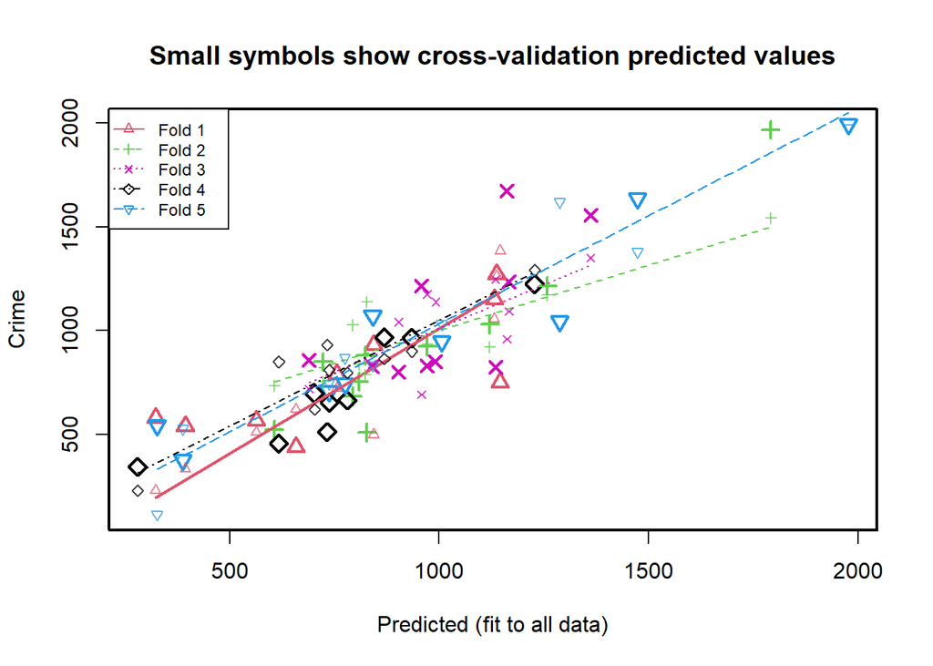

```
##
## fold 1
## Observations in test set: 9
##                     1        3       17       18        19        22         36
## Predicted   755.03222 322.2615 393.3633 843.8072 1145.7379  657.2092 1137.61711
## cvpred      719.48189 227.3811 334.2928 497.4904 1384.9349  620.1834 1261.61602
## Crime       791.00000 578.0000 539.0000 929.0000  750.0000  439.0000 1272.00000
## CV residual  71.51811 350.6189 204.7072 431.5096 -634.9349 -181.1834   10.38398
##                   38         40
## Predicted   562.6934 1131.45326
## cvpred      509.0826 1057.08701
## Crime       566.0000 1151.00000
## CV residual  56.9174   93.91299
##
## Sum of squares = 804290.7    Mean square = 89365.64    n = 9
##
## fold 2
## Observations in test set: 10
##                     4         6        12        25         28        32
## Predicted   1791.3619  792.9301 722.04080  605.8824 1258.48423 807.81667
## cvpred      1542.8663 1025.6864 752.84607  733.1797 1170.10415 836.60938
## Crime       1969.0000  682.0000 849.00000  523.0000 1216.00000 754.00000
## CV residual  426.1337 -343.6864  96.15393 -210.1797   45.89585 -82.60938
##                    34        41        44        46
## Predicted   971.45581 823.74192 1120.8227  827.3543
## cvpred      934.62797 786.74042  919.1066 1137.6778
## Crime       923.00000 880.00000 1030.0000  508.0000
## CV residual -11.62797  93.25958  110.8934 -629.6778
##
## Sum of squares = 779686.2    Mean square = 77968.62    n = 10
##
## fold 3
## Observations in test set: 10
##                     5         8        9        11        15        23
## Predicted   1166.6840 1361.7468 688.8682 1161.3291  903.3541  957.9918
## cvpred      1092.1924 1349.7715 717.0401  958.3058 1040.2775  690.2073
## Crime       1234.0000 1555.0000 856.0000 1674.0000  798.0000 1216.0000
## CV residual  141.8076  205.2285 138.9599  715.6942 -242.2775  525.7927
##                    37       39        43        47
## Predicted    971.1513 839.2864 1134.4172  991.7629
```

[output cut: 24 more lines]

```
## Predicted   1473.6764 736.50802 1005.65694  774.8506 1977.37067 1287.3917
## cvpred      1379.5108 743.27567 1031.35676  867.6315 1975.12567 1619.8299
## Crime       1635.0000 705.00000  946.00000  742.0000 1993.00000 1043.0000
## CV residual  255.4892 -38.27567  -85.35676 -125.6315   17.87433 -576.8299
##                    31        33       42
## Predicted    388.0334  840.9992 326.3324
## cvpred       525.4791  830.6871 112.9800
## Crime        373.0000 1072.0000 542.0000
## CV residual -152.4791  241.3129 429.0200
##
## Sum of squares = 688401.1    Mean square = 76489.01    n = 9
##
## Overall (Sum over all 9 folds)
##       ms
## 84948.87
```

```r
cv_results
```

[output not shown]

[output cut: 81 more lines]

```r
# Remove all objects from the current workspace
rm(list = ls())

# Load necessary libraries
library(DAAG)

# Read the data from the specified file path into a data frame
uscrime <- read.table("C://Users//Clair//OneDrive//Documents//GitHub//omsa//ISYE 6501//Homework 5//uscrime.txt", stringsAsFactors = FALSE, header = TRUE)

# Fit a linear model to the data with 'Crime' as the response variable and selected predictors
lm_uscrime_2 <- lm(Crime ~ M + Ed + Po1 + U2 + Ineq + Prob, data = uscrime)

# Display the linear model object
lm_uscrime_2
```

```
##
## Call:
## lm(formula = Crime ~ M + Ed + Po1 + U2 + Ineq + Prob, data = uscrime)
##
## Coefficients:
## (Intercept)            M           Ed          Po1           U2         Ineq
##    -5040.50       105.02       196.47       115.02        89.37        67.65
##        Prob
##    -3801.84
```

```r
# Display a summary of the linear model, including coefficients, R-squared, etc.
summary(lm_uscrime_2)
```

```
##
## Call:
## lm(formula = Crime ~ M + Ed + Po1 + U2 + Ineq + Prob, data = uscrime)
##
## Residuals:
##     Min      1Q  Median      3Q     Max
## -470.68  -78.41  -19.68  133.12  556.23
##
## Coefficients:
##             Estimate Std. Error t value Pr(>|t|)
## (Intercept) -5040.50     899.84  -5.602 1.72e-06 ***
## M             105.02      33.30   3.154  0.00305 **
## Ed            196.47      44.75   4.390 8.07e-05 ***
## Po1           115.02      13.75   8.363 2.56e-10 ***
## U2             89.37      40.91   2.185  0.03483 *
## Ineq           67.65      13.94   4.855 1.88e-05 ***
## Prob        -3801.84    1528.10  -2.488  0.01711 *
## ---
## Signif. codes:  0 '***' 0.001 '**' 0.01 '*' 0.05 '.' 0.1 ' ' 1
##
## Residual standard error: 200.7 on 40 degrees of freedom
## Multiple R-squared:  0.7659, Adjusted R-squared:  0.7307
## F-statistic: 21.81 on 6 and 40 DF,  p-value: 3.418e-11
```

```r
# Create a new data frame with a test point for prediction
test_point <- data.frame(M = 14.0,
                         So = 0,
                         Ed = 10.0,
                         Po1 = 12.0,
                         Po2 = 15.5,
                         LF = 0.640,
                         M.F = 94.0,
                         Pop = 150,
                         NW = 1.1,
                         U1 = 0.120,
                         U2 = 3.6,
                         Wealth = 3200,
                         Ineq = 20.1,
                         Prob = 0.04,
                         Time = 39.0)

# Use the linear model to predict the 'Crime' value for the test point
pred_model_2 <- predict(lm_uscrime_2, test_point)
pred_model_2
```

```
##        1
## 1304.245
```

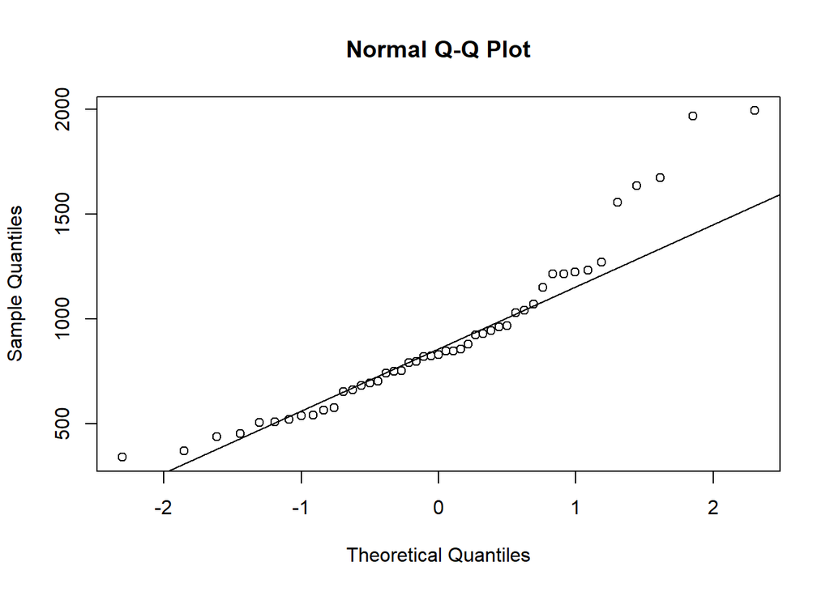

```r
# Check the normality of the 'Crime' variable in the dataset using a Q-Q plot
qqnorm(uscrime$Crime)
qqline(uscrime$Crime)
```

```r
# Calculate the total sum of squares (SST)
total_sum_squared_diff <- sum((uscrime$Crime - mean(uscrime$Crime))^2)
total_sum_squared_diff
```

```
## [1] 6880928
```

```r
# Calculate the sum of squares of the residuals (SSE)
sum_squared_residuals_2 <- sum(residuals(lm_uscrime_2)^2)

# Calculate R-squared
r_squared_2 <- 1 - (sum_squared_residuals_2 / total_sum_squared_diff)
r_squared_2
```

```
## [1] 0.7658663
```

```r
# Perform 5-fold cross-validation
set.seed(42)
cv_results_2 <- cv.lm(uscrime, lm_uscrime_2, m = 5)
```

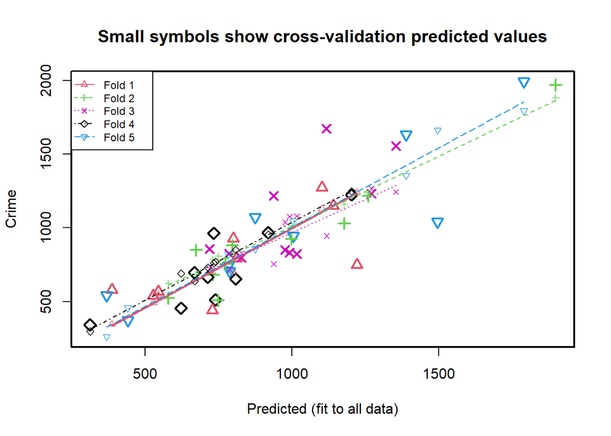

```
##
## fold 1
## Observations in test set: 9
##                      1        3       17       18        19        22        36
## Predicted   810.825487 386.1368 527.3659 800.0046 1220.6767  728.3110 1101.7167
## cvpred      785.364736 345.3417 492.2016 700.5751 1240.2916  701.5126 1127.3318
## Crime       791.000000 578.0000 539.0000 929.0000  750.0000  439.0000 1272.0000
## CV residual   5.635264 232.6583  46.7984 228.4249 -490.2916 -262.5126  144.6682
##                    38         40
## Predicted   544.37325 1140.79061
## cvpred      544.69903 1168.21107
## Crime       566.00000 1151.00000
## CV residual  21.30097  -17.21107
##
## Sum of squares = 439507.2    Mean square = 48834.14    n = 9
##
## fold 2
## Observations in test set: 10
##                      4         6       12        25         28        32
## Predicted   1897.18657 730.26589 673.3766 579.06379 1259.00338 773.68402
## cvpred      1882.73805 781.75573 684.3525 621.37453 1238.31917 788.03429
## Crime       1969.00000 682.00000 849.0000 523.00000 1216.00000 754.00000
## CV residual   86.26195 -99.75573 164.6475 -98.37453  -22.31917 -34.03429
##                     34       41        44        46
## Predicted    997.54981 796.4198 1177.5973  748.4256
## cvpred      1013.92532 778.0437 1159.3155  807.6968
## Crime        923.00000 880.0000 1030.0000  508.0000
## CV residual  -90.92532 101.9563 -129.3155 -299.6968
##
## Sum of squares = 181038.4    Mean square = 18103.83    n = 10
##
## fold 3
## Observations in test set: 10
##                      5         8        9        11        15        23
## Predicted   1269.84196 1353.5532 718.7568 1117.7702 828.34178  937.5703
## cvpred      1266.79544 1243.1763 723.5331  946.1309 826.28548  754.2511
## Crime       1234.00000 1555.0000 856.0000 1674.0000 798.00000 1216.0000
## CV residual  -32.79544  311.8237 132.4669  727.8691 -28.28548  461.7489
##                    37       39        43        47
## Predicted    991.5623 786.6949 1016.5503  976.4397
```

[output cut: 24 more lines]

```
## Predicted   1387.8082 787.27124 1004.3984 783.27334 1789.1406 1495.4856
## cvpred      1355.7097 723.66781 1046.8197 819.71145 1794.6456 1663.6272
## Crime       1635.0000 705.00000  946.0000 742.00000 1993.0000 1043.0000
## CV residual  279.2903 -18.66781 -100.8197 -77.71145  198.3544 -620.6272
##                   31        33       42
## Predicted   440.4394  873.8469 368.7031
## cvpred      456.5736  857.7052 260.9211
## Crime       373.0000 1072.0000 542.0000
## CV residual -83.5736  214.2948 281.0789
##
## Sum of squares = 650990    Mean square = 72332.23    n = 9
##
## Overall (Sum over all 9 folds)
##       ms
## 53586.08
```

```r
cv_results_2
```

[output not shown]

[output cut: 81 more lines]

References:

[1] “Microsoft CoPilot. Accessed 2024-9-22. Prompt: ‘climbing frequency, training hours, rest days, body measurements, onsight difficulty are independent variables to my climbing difficulty (dependency variable) write my linear regression formula in markeddown sytnax’ Generated using https://copilot.microsoft.com/.”

[2] “Microsoft CoPilot. Accessed 2024-9-23. Prompt: ‘r squared formula in markeddown syntax’ Generated using https://copilot.microsoft.com/.”